#### Data Structure

- `Krackhardt_HighTech` is a list
  - `Advice`, in matrix form, is an element of the list `Krackhardt_HighTech`
  - `Friendship`, in matrix form, is an element of the list `Krackhardt_HighTech`
  - `ReportTo`, in matrix form, is an element of the list `Krackhardt_HighTech`
  - `Attrobutes` is an element of the list `Krackhardt_HighTech`

```r
Krackhardt_HighTech$Advice
```

```
##     A01 A02 A03 A04 A05 A06 A07 A08 A09 A10 A11 A12 A13 A14 A15 A16 A17 A18 A19
## A01   0   1   0   1   0   0   0   1   0   0   0   0   0   0   0   1   0   1   0
## A02   0   0   0   0   0   1   1   0   0   0   0   0   0   0   0   0   0   0   0
## A03   1   1   0   1   0   1   1   1   1   1   1   1   0   1   0   0   1   1   0
## A04   1   1   0   0   0   1   0   1   0   1   1   1   0   0   0   1   1   1   0
## A05   1   1   0   0   0   1   1   1   0   1   1   0   1   1   0   1   1   1   1
## A06   0   0   0   0   0   0   0   0   0   0   0   0   0   0   0   0   0   0   0
## A07   0   1   0   0   0   1   0   0   0   0   1   1   0   1   0   0   1   1   0
## A08   0   1   0   1   0   1   1   0   0   1   1   0   0   0   0   0   0   1   0
## A09   1   1   0   0   0   1   1   1   0   1   1   1   0   1   0   1   1   1   0
## A10   1   1   1   1   1   0   0   1   0   0   1   0   1   0   1   1   1   1   1
## A11   1   1   0   0   0   0   1   0   0   0   0   0   0   0   0   0   0   0   0
## A12   0   0   0   0   0   0   1   0   0   0   0   0   0   0   0   0   0   0   0
## A13   1   1   0   0   1   0   0   0   1   0   0   0   0   1   0   0   0   1   0
## A14   0   1   0   0   0   0   1   0   0   0   0   0   0   0   0   0   0   1   0
## A15   1   1   1   1   1   1   1   1   1   1   1   1   1   1   0   1   1   1   1
## A16   1   1   0   0   0   0   0   0   0   1   0   0   0   0   0   0   0   1   0
## A17   1   1   0   1   0   0   1   0   0   0   0   0   0   0   0   0   0   0   0
## A18   1   1   1   1   1   0   1   1   1   1   1   0   1   1   1   1   0   0   1
## A19   1   1   1   0   1   0   1   0   0   1   1   0   0   1   1   0   0   1   0
## A20   1   1   0   0   0   1   0   1   0   0   1   1   0   1   1   1   1   1   0
## A21   0   1   1   1   0   1   1   1   0   0   0   1   0   1   0   0   1   1   0
##     A20 A21
## A01   0   1
## A02   0   1
## A03   1   1
## A04   1   1
## A05   1   1
## A06   0   1
## A07   0   1
## A08   0   1
## A09   0   1
## A10   1   0
## A11   0   0
## A12   0   1
## A13   0   0
## A14   0   1
## A15   1   1
## A16   0   0
## A17   0   1
## A18   1   1
## A19   1   0
## A20   0   1
## A21   1   0
```

```r
table(Krackhardt_HighTech$Advice)
```

```
##
##   0   1
## 251 190
```

```r
# We get this:
#   0   1
# 251 190
```

```r
#read in more data
Krackhardt_HighTech$Friendship = as.matrix(
  read.csv("Krackhardt_HighTech_Friendship.csv",
           stringsAsFactors=FALSE, row.names=1)
  )

Krackhardt_HighTech$ReportTo = as.matrix(
  read.csv("Krackhardt_HighTech_ReportTo.csv",
           stringsAsFactors=FALSE, row.names=1)
  )

Krackhardt_HighTech$Attributes = read.csv(
  "Krackhardt_HighTech_Attributes.csv",
  stringsAsFactors=FALSE, row.names=1
  )
```

#### Note

Why specifying `stringsAsFactors=FALSE`? R has, at least by default, converted (character) strings to factors when creating data frames directly with `data.frame()`.

```r
#### some outputs
Krackhardt_HighTech$Attributes
```

```
##     Age Tenure Level Department
## A01  33  9.333     3          4
## A02  42 19.583     2          4
## A03  40 12.750     3          2
## A04  33  7.500     3          4
## A05  32  3.333     3          2
## A06  59 28.000     3          1
## A07  55 30.000     1          0
## A08  34 11.333     3          1
## A09  62  5.417     3          2
## A10  37  9.250     3          3
## A11  46 27.000     3          3
## A12  34  8.917     3          1
## A13  48  0.250     3          2
## A14  43 10.417     2          2
## A15  40  8.417     3          2
## A16  27  4.667     3          4
## A17  30 12.417     3          1
## A18  33  9.083     2          3
## A19  32  4.833     3          2
## A20  38 11.667     3          2
## A21  36 12.500     2          1
```

```r
table(Krackhardt_HighTech$Attributes$Level)
```

```
##
##  1  2  3
##  1  4 16
```

```r
Krackhardt_HighTech
```

```
## $Advice
##     A01 A02 A03 A04 A05 A06 A07 A08 A09 A10 A11 A12 A13 A14 A15 A16 A17 A18 A19
## A01   0   1   0   1   0   0   0   1   0   0   0   0   0   0   0   1   0   1   0
## A02   0   0   0   0   0   1   1   0   0   0   0   0   0   0   0   0   0   0   0
## A03   1   1   0   1   0   1   1   1   1   1   1   1   0   1   0   0   1   1   0
## A04   1   1   0   0   0   1   0   1   0   1   1   1   0   0   0   1   1   1   0
## A05   1   1   0   0   0   1   1   1   0   1   1   0   1   1   0   1   1   1   1
## A06   0   0   0   0   0   0   0   0   0   0   0   0   0   0   0   0   0   0   0
## A07   0   1   0   0   0   1   0   0   0   0   1   1   0   1   0   0   1   1   0
## A08   0   1   0   1   0   1   1   0   0   1   1   0   0   0   0   0   0   1   0
## A09   1   1   0   0   0   1   1   1   0   1   1   1   0   1   0   1   1   1   0
## A10   1   1   1   1   1   0   0   1   0   0   1   0   1   0   1   1   1   1   1
## A11   1   1   0   0   0   0   1   0   0   0   0   0   0   0   0   0   0   0   0
## A12   0   0   0   0   0   0   1   0   0   0   0   0   0   0   0   0   0   0   0
## A13   1   1   0   0   1   0   0   0   1   0   0   0   0   1   0   0   0   1   0
## A14   0   1   0   0   0   0   1   0   0   0   0   0   0   0   0   0   0   1   0
## A15   1   1   1   1   1   1   1   1   1   1   1   1   1   1   0   1   1   1   1
## A16   1   1   0   0   0   0   0   0   0   1   0   0   0   0   0   0   0   1   0
## A17   1   1   0   1   0   0   1   0   0   0   0   0   0   0   0   0   0   0   0
## A18   1   1   1   1   1   0   1   1   1   1   1   0   1   1   1   1   0   0   1
## A19   1   1   1   0   1   0   1   0   0   1   1   0   0   1   1   0   0   1   0
## A20   1   1   0   0   0   1   0   1   0   0   1   1   0   1   1   1   1   1   0
## A21   0   1   1   1   0   1   1   1   0   0   0   1   0   1   0   0   1   1   0
##     A20 A21
## A01   0   1
## A02   0   1
## A03   1   1
## A04   1   1
## A05   1   1
## A06   0   1
## A07   0   1
## A08   0   1
## A09   0   1
## A10   1   0
## A11   0   0
## A12   0   1
## A13   0   0
## A14   0   1
## A15   1   1
## A16   0   0
```

[output cut: 106 more lines]

```
## A07  55 30.000     1          0
## A08  34 11.333     3          1
## A09  62  5.417     3          2
## A10  37  9.250     3          3
## A11  46 27.000     3          3
## A12  34  8.917     3          1
## A13  48  0.250     3          2
## A14  43 10.417     2          2
## A15  40  8.417     3          2
## A16  27  4.667     3          4
## A17  30 12.417     3          1
## A18  33  9.083     2          3
## A19  32  4.833     3          2
## A20  38 11.667     3          2
## A21  36 12.500     2          1
```

#### III. Network Visualization

```r
# Installing and "activate" packages
#install.packages("igraph")
#install.packages("sna")
library(igraph)
library(sna)
```

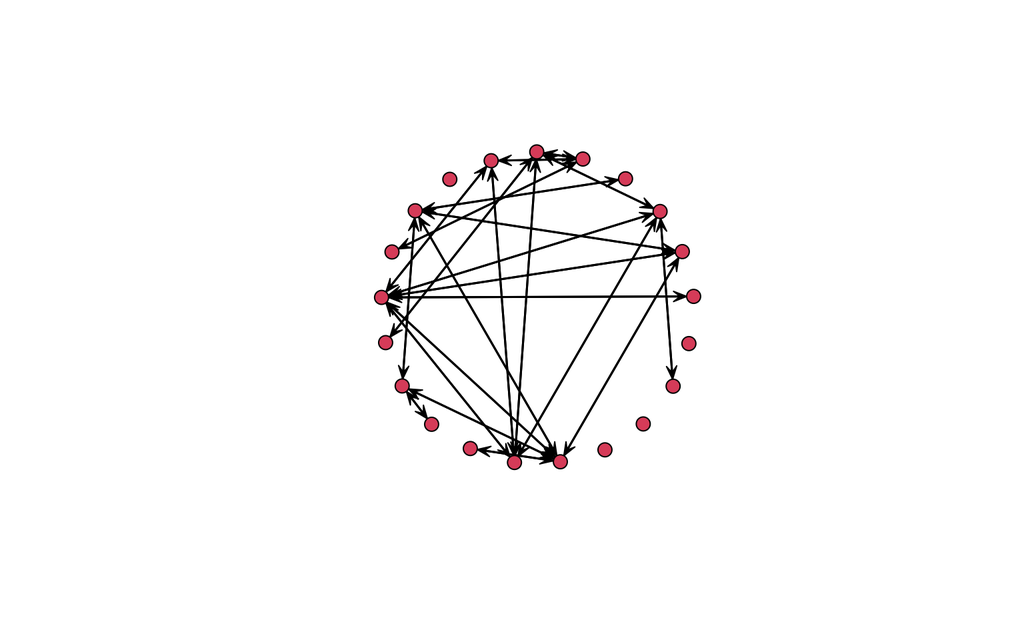

```r
# Symmetrizing the Friendship network
Krackhardt_HighTech$Friendship_SymMin = (Krackhardt_HighTech$Friendship)*t(Krackhardt_HighTech$Friendship) #t: Matrix Transpose

# 1. Plotting using the "sna" package
gplot(Krackhardt_HighTech$Friendship_SymMin, mode = "circle")
```

```r
# If you get the warning "Error in plot.new() : figure margins too large"
# -> Increase the size of your "Plots" window in RStudio
```

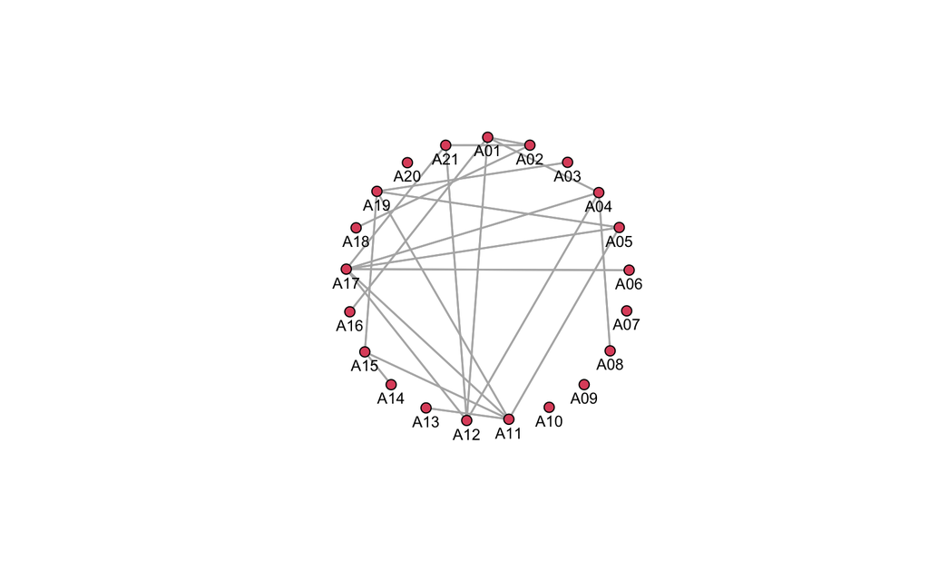

```r
# Let's improve our picture a bit
gplot(Krackhardt_HighTech$Friendship_SymMin,
      gmode = "graph",           # type of network: undirected #digraph: directed
      mode = "circle",           # how the nodes are positioned
      vertex.cex = 0.8,           # the size of the node shapes
      displaylabels = TRUE,      # to add the node labels
      label.pos = 1,             # to position the labels below the node shapes
      label.cex = 0.8,            # to decrease the size of the node labels
      edge.col = "grey70")       # to make the color of the ties/edges 30% black and 70% white
```

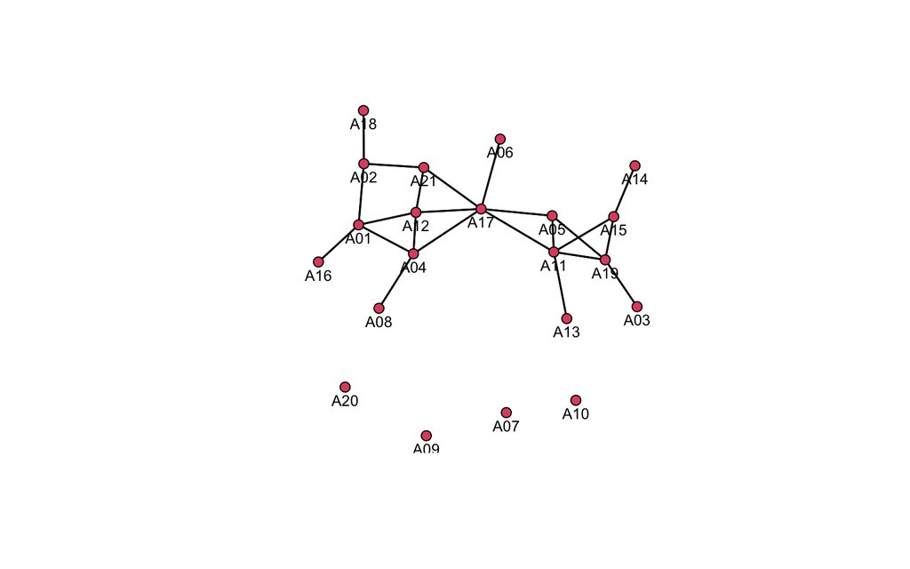

```r
# Let's improve our picture a bit more
gplot(Krackhardt_HighTech$Friendship_SymMin,
      gmode = "graph",           # type of network: undirected
      vertex.cex= 0.8,           # the size of the node shapes
      displaylabels = TRUE,      # to add the node labels
      label.pos = 1,             # to position the labels below the node shapes
      label.cex = 0.8,            # to decrease the size of the node labels
      edge.color = "grey70")       # to make the color of the ties/edges 30% black and 70% white
```

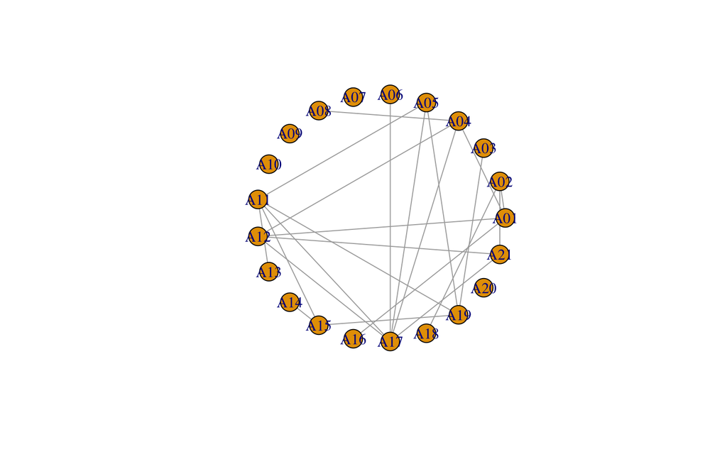

```r
# 2. Plotting using the "igraph" package
#########################################
KHF_SymMin_i = graph_from_adjacency_matrix(Krackhardt_HighTech$Friendship_SymMin,
                                          mode="undirected", diag=FALSE)
#########################################
# Let's inspect the "igraph" object that was created:
plot(KHF_SymMin_i, layout = layout_in_circle)
```

```r
KHF_SymMin_i
```

```
## IGRAPH 6c1438b UN-- 21 23 --
## + attr: name (v/c)
## + edges from 6c1438b (vertex names):
##  [1] A01--A02 A01--A04 A01--A12 A01--A16 A02--A18 A02--A21 A03--A19 A04--A08
##  [9] A04--A12 A04--A17 A05--A11 A05--A17 A05--A19 A06--A17 A11--A13 A11--A15
## [17] A11--A17 A11--A19 A12--A17 A12--A21 A14--A15 A15--A19 A17--A21
```

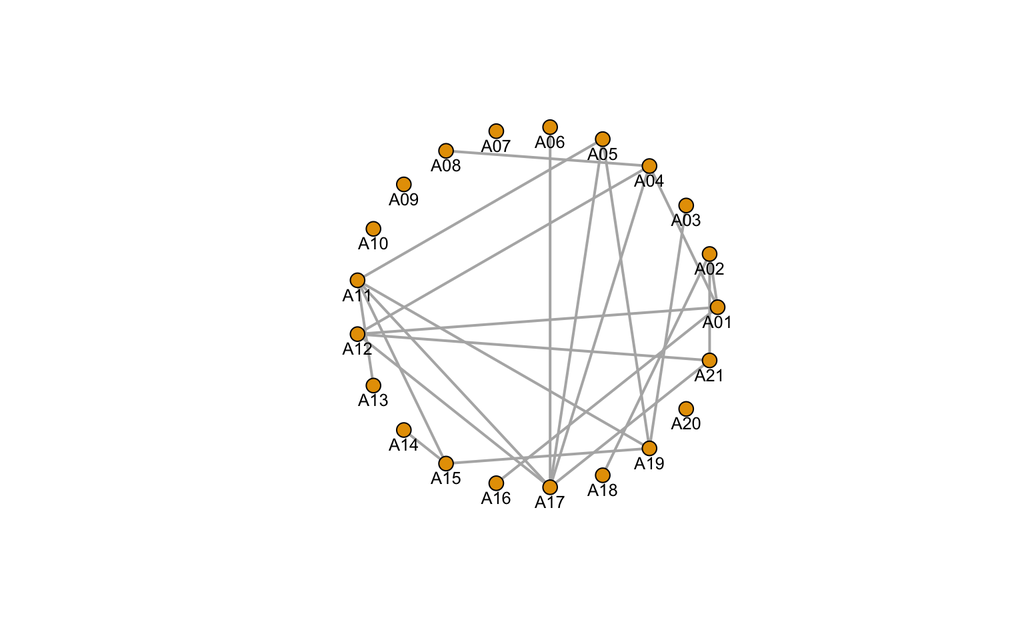

```r
# Improving the plot
plot(KHF_SymMin_i,
     layout = layout_in_circle,       # how the nodes are positioned
     vertex.size = 8,                 # the size of the node shapes
     vertex.label.cex = 0.8,          # to decrease the size of the node labels
     vertex.label.family = "",        # change the font (default is Times New Roman here)
     vertex.label.color = "black",    # change the color of the labels to black (default blue)
     vertex.label.dist=1.1,         # change the distance of the labels from the center of the node shape (default is 0)
     vertex.label.degree=pi/2,      # to position the labels below the node shapes
     edge.color="grey70",           # to make the color of the ties/edges 30% black and 70% white
     edge.width=2)                  # increase the width of the ties/edges.
```

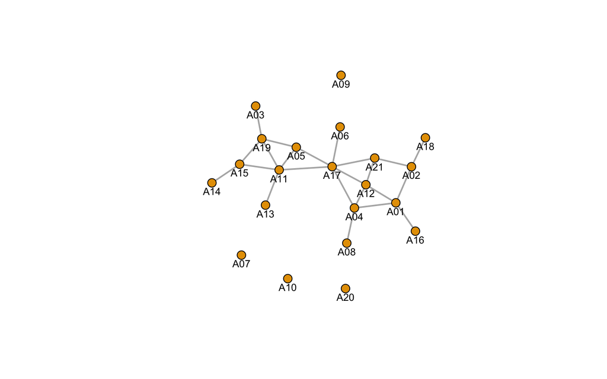

```r
# Improving the plot
plot(KHF_SymMin_i,
     vertex.size = 8,                 # the size of the node shapes
     vertex.label.cex = 0.8,          # to decrease the size of the node labels
     vertex.label.family = "",        # change the font (default is Times New Roman here)
     vertex.label.color = "black",    # change the color of the labels to black (default blue)
     vertex.label.dist = 1.1,         # change the distance of the labels from the center of the node shape (default is 0)
     vertex.label.degree = pi/2,      # to position the labels below the node shapes
     edge.color = "grey70",           # to make the color of the ties/edges 30% black and 70% white
     edge.width = 2)                  # increase the width of the ties/edges.
```

```r
## threejs
#data(KHF_SymMin_i)
#graphjs(KHF_SymMin_i, bg="black")
```

#### EXERCISES

- Use the extra datasets provided in dropbox.
- Go to the website: https://rpubs.com/ASNR2022/Chapter7_Practice
- or https://sites.google.com/view/asnr-2022/home/7-visualization/practice-7-1-visualization
- and check out some more advanced ways to visualize networks.

```r
# EXERCISES



#for example read in the Wolfe_Primates and then select the JointPresence network.

#gplot(Wolfe_Primates$JointPresence>6,
#      gmode="graph",                                      # type of network: undirected
#      coord=Wolfe_Primates$Attributes[,c(2,4)],           # coordinates to be use
#      vertex.cex=.8,                                      # the size of the node shapes
#      vertex.col=(Wolfe_Primates$Attributes$Gender==1)*8, # a vector which is used to

#define the color of each node (0=white and 8=grey)
#      displaylabels=TRUE,                                 # to add the node labels
#      label.pos=1,                                        # to position the labels below the node shapes
#      label.cex=.7,                                       # to decrease the size of the node labels to 50% of the default
#      edge.col="grey70")                                  # to make the color of the ties/edges 30% black and 70% white
```

#### END OF SCRIPT 1

**Eric Hsienchen Chu**

UW-Madison @Economics

Editor-in-Chief | UW Equilibrium: The Undergraduate Journal of Economics

[Previous Editions](https://issuu.com/uwequilibrium.com) | [Online Journal](https://equilibriumecon.wisc.edu/)